# Deep Learning- 課程 07－Deep Learning- Fast Faster R-CNN - Python Tutorial

''' 人工智慧- 進階課程 A.I Tutorials - Advanced Course - Deep Learning 教程 ''' 05 - 深度學習 教程 課程 07 - Deep Learning- - Fast/Faster R-CNN - Region Proposals CNN - Fast/Faster R-CNN - Region Proposals CNN - 區域提議 + 卷積神經網絡 程式範例 - Fast/Faster R-CNN - Objection Detection – Image - GluonCV - 目標檢測 - 圖像 ''' ''' >> 資料準備 >> 你我互動學習園地- 進階課程 Advanced Course >> https://interactiveuandmetutorialsac.weebly.com/ >> 你我互動學習園地 >> https://interactiveuandmetutorials.weebly.com/ >> Python 程式語言 設計 >> https://pythonprogrammingtutorials.weebly.com/ >> 目錄結構 : >> Deep Learning- 課程 07－Deep Learning- Fast/Faster R-CNN.zip 檔案路徑/ ├── 課程 07－Deep Learning-Fast/Faster R-CNN.ipynb └── images/ ├── dog.jpg ├── peson.jpg └── biking.jpg ''' ''' >> R-CNN 系列 - 模型摘要 >> R-CNN Family '''

[figure not shown]

''' >> One-Stage Object Detection Quick View >> Two-Stage Object Detection Quick View '''

[figure not shown]

''' - R- CNN Quick Rivew '''''' >> R-CNN 物體檢測 - Object Detection - 速度很慢 - R-CNN 一開始必須先產生約 2000 個區域 - 每個區域都要 - 丟進 CNN 中 - 擷取特徵 - 至少 2000 次的 - CNN - 難以訓練 - Model - 分開成三部份 - CNN 取出特徵的 - CNN - SVM 分類的 SVM - Bounding Box 優化 - 的線性回歸。 - R-CNN 不容易作訓練 - 儲存容量存 - 需求 - 保存 - 每個區域建議 - 每個特徵圖 - 需要大量的內存 - 儲存容量 '''

''' >> R-CNN 系統 - R-CNN System '''

[figure not shown]

''' - 比較 - Comparsion >> R-CNN System >> Fast R-CNN System '''''' >> Fast R-CNN 系統 - System >> Fast R-CNN 解決 R-CNN運算效能 - 優化的演算法 - R-CNN 計算 2000個 - Region proposal - 放入 CNN - 需要 個別運算 -很多重複的區域 - Fast R-CNN - 只運算 一次 CNN - CNN 擷取出來 的特徵 - 2000 個Region proposal - 做運用 - 利用 RoIpooling (Region of Interest Pooling) - 取出的 Region - 對應到 Feature map 輸出後 - 各自 - 接上 FC 去做 - Softmax分類 - bbox Regressor '''

[figure not shown]

''' >> 圖像的特徵圖 - Feature Map - CNN 輸入 和 輸出 - 對於每個區域建議，從特徵圖中提取相應的部分 - 稱為 - 區域提議特徵圖 - Region Proposal Feature Map - 獲取區域提議要素地圖 - Region Proposal Feature Map - 並在 - 池化層 Pooling Layer 下 - 調整為固定大小 - Resize it to a Fixed size '''

[figure not shown]

''' >> Pooling Layer - 池層 - Region of interest (RoI) - Pooling Layer '''

[figure not shown]

''' >> 固定大小的區域提議特徵圖 - 展平 Flatten - 特徵向量 - 具有相同的大小 >> 特徵向量 - 最後一部分的輸入 - 2個輸出 - 完全連接的層 - Fully Connected Layers - Softmax Classification - 對像類 - Object Class - 邊界框回歸器 - Bounding Box Regressor - 輸出 - 每個對像類的邊界框坐標 - Bounding Box Coordinates >> Faster R-CNN訓練 - VGG16 - 網絡速度 - R-CNN x9 倍 '''

[figure not shown]

''' >> Fast R-CNN - Selective Search - 選出 ~ 2000個 - Region Proposal - 只需要計算一次CNN - RoIpooling 對應到 Feature map - 因為 Region Proposal的 - x, y, h, w - 通常是 小數 - 因此 在對應 Feature map之前 - 會先取一次整數 - 整數化後的 - 邊界平均分割成k x k個單元 - 對每一個單元的邊界做整數化 - 如下圖 - 經過取整數之後 - 特徵位置 - Feature Map 所對應的位置 - 會有所偏差， - 後來就演進了 - RoIAlign '''

[figure not shown]

''' >> Fast R-CNN - 演算法結構 '''

[figure not shown]

''' >> Fast R-CNN - 演算法 基本上 >> 重要的改變 - 拿掉 SVM - 改以 Softmax - Classification - NN - 一樣是 Selective Search - Region Proposals - ROI (Region of Interest) - 改為 -先將整張影像通過conv.得到feature map後 - 將 ROI 映射在 map 上來取真正要用的ROI - 一張影像 只須過一次Convolution - 省掉 - 很多的計算 成本 >> 利用 ROI pooling layer - 來統一 ROI - 送進 Fully Connected Layer (FC)層前的維度 '''''' >> Backbone Network - VGG16 >> ROI Pooling Layer >> Detector '''

[figure not shown]

''' - Backbone Network - VGG16 '''

[figure not shown]

''' - ROI Pooling Layer >> ROI - 可能是 - 不同的長寬構成的框 - VGGnet - FC 層 Layer - 以 7x7 的 Feature Map 為 輸入 Input - 在 ROI Pooling Layer 中 - 14x14 的 Feature Map 上 - 切出 ROI 後 - Pooling 將 - ROI 輸出成 - 7 x 7 '''

[figure not shown]

''' - Detector >> 分類器 - FC層 - 分成兩輸出 - 進行 - 分類器 - 原本的 SVM - 改成了 FC層 - softmax - bbox regressor '''

[figure not shown]

''' >> Fast R-CNN 的速度 - 比 R-CNN 的速度 - 快上 25倍 >> 最後 - 總結一下 Fast R-CNN 重點 - 改變 ROI Sampling 的邏輯 - 原本要 - 重複運作2000次的特徵提取 - 變成只對原始影像做一次特徵提取 - 圖上的 Region Proposals - 映射 到 Feature Maps上做 Sampling >> ROI pooling層 統一 ROI 送進 FC層的維度 >> 多目標的 Loss Function - 原本 R-CNN 的 多層訓練 - 變成簡單的 Back-Propagation >> Fast R-CNN 的 mAP - 比 R-CNN 略高一點 - 速度 加快很多(2s/image) - 訓練的速度 - 也增加了 將近 9倍的時間 >> Fast RCNN 的優點是： >> 只需要作一次 CNN - 有效解省運算時間 >> 使用單一網絡 - 簡化訓練過程 '''''' >> But - 快速 Fast R-CNN - 在訓練和測試時間上 - 都快得多 - 但是 , 改進並不顯著 - 因為 區域提案 是由另一種模型分別生成的 - 而且非常昂貴 '''

''' - Quick View - R-CNN系列 - 模型摘要 - R-CNN Family '''

[figure not shown]

''' >> Faster R-CNN 模型 - 一個直觀的加速解決方案 - CNN 預先篩選 Region Proposals - CNN 的 Feature Map 上選出 Region Proposals - Region proposal algorithm - RPN - Region Proposal Network - CNN model 模型 - Fast R-CNN with shared convolutional Feature Layers '''''' >> RPN -Region Proposal Network - 代替 - Selective Search - 2000 個 - 候選區域 - Select search - 找出 - 2000個 Region Proposal 候選區域 - CPU - 2s - RPN - region proposal network - CPU - 10ms - 每張圖像 '''

[figure not shown]

''' >> Faster R-CNN 基本上 - 可以分為四個部分 - Conv Layers - Input Image [P, Q] - Reshape 成 [M, N] - 記錄 Rescale Factor - im_info裡 - 作為 Proposal Layer - 到 RoIPooling 對齊位置所需要的資訊 - 經過 13 Conv, 13 Relu, 4 Maxpooling - 提取 Feature Map - Region Proposal Network - 與Fast R-CNN最大的不同 - 使用 RPN 生成 Region Proposals - RPN 使用 Softmax 判別 - Positive Anchor - Negative Anchor， - 使用bbox regression － 修正anchor 的位置資訊 - 得到更精準的位置 - RoIPooling - 收集 Feature Maps 與 RPN - 的結果 - 送入 FC 進行訓練 - Classification： - RoIPooling - 輸入的數值 - 進行分類 - bbox regression - 獲得最佳物體位置 '''''' - Conv layers - 所有的conv層都是 - kernel size =3, pad=1, stride=1 - 經過conv層後 - 影像大小不變 - 所有的pooling層 - 都是 - kernel size =2, pas=0, stride=2 - 濃縮影像資訊 - 圖中 － 代表 － 經過 4次 Pooling 過程 - Feature map 的大小 - [M/(2⁴),N/(2⁴)] '''

[figure not shown]

''' >> R-CNN, Fast R-CNN - 都是使用 Selective Search(SS)非常消耗時間 - Faster R-CNN - 直接使用 NN - 尋找 Positive Anchor - 生成 Region Proposal - Region Proposal Network - RPN - Region Proposal Network - 是一個 Convolution Network - Input - CNN 輸出的 Feature Map - 輸出 - 一個 Bounding Box - Bounding Box - 包含一個物體的機率 '''

[figure not shown]

''' - RPN - 分為兩個部分 - Anchor 的選擇 - Anchor 的定位 >> RPN - Region Proposal Network - Anchor box - Anchor box - 一個維度為[N, 4]的矩陣 - 如下 - 若有九個種 Anchor box - 四個值分別代表(x1,y1,x2,y2) - 代表box 的 左上 和 右下 座標位置 - Anchor box 的尺寸設定 - 根據 輸入影像大小 做調整 '''

[figure not shown]

[[ -84. -40. 99. 55.] [-176. -88. 191. 103.] [-360. -184. 375. 199.] [ -56. -56. 71. 71.] [-120. -120. 135. 135.] [-248. -248. 263. 263.] [ -36. -80. 51. 95.] [ -80. -168. 95. 183.] [-168. -344. 183. 359.]] - 同一個點上有 k個 Anchor Box - 每個點需要判斷是否為 Positive or Negative - 因此就有 Class = 2k Scores - 每個 Anchor Box座標 - 需要做 - 回歸校正 - reg = 4k coordinates

''' - RPN - 原圖- 布滿了 - Anchor - CNN (VGG16 , ResNet50...etc) - 分辨 - 哪些 Anchor 是 - 是 Positive 輸出 Output '''

[figure not shown]

''' - Anchor Classification(cls) - 18 數值 - 鑑別 - 每一個 Anchor - 檢測 9 個 Anchor box - 同時 - 個別有 Positive及 Negative - 分數 - 合起來 - 18 個值 - RPN - 利用 1x1 Kernel - 展開 18個 數值 '''

[figure not shown]

''' >> Bounding Box Regression(reg) - 紅色 - Positive Anchor - 綠色 - Ground Truth， - 即使紅色區域被辨識為飛機 - 但因為紅色框框的定位效果不佳 - 因此在 IOU 的 - 表現不佳 - 等於並 - 沒有正確的偵測出飛機 - 因此有了 - Bounding Box Regression '''

[figure not shown]

''' - bbox Regression 架構 - Anchor classification - anchor box - 9個 - 4個位置 = 9 X 4 = 36 '''

[figure not shown]

''' - Proposal Layer '''

[figure not shown]

''' >> Proposal layer 輸入值 - rpn_cls_prob_reshape : Anchor Positive / Negative result - rpn_bbox_pre : bbox Regression - im_info : Input Image [P, Q]裁減之後 - 變為[M,N] - 的 Scale factor - 幾次 - Pooling '''''' >> Proposal Layer - 流程 - 生成 Anchors - Anchors - 做 bbox regression - 按照輸入的 Psitive Softmax Scores 排序 - 挑出需要的 Anchors(修正位置過後) - 限定超出圖像邊界的 - Positive Anchors為圖像邊界 - 防 - 後續的 RoIpooling 超出範圍 - 除去邊界範圍極小的 - Positive Anchors - Non-Maximum Suppression - nms - 判別 - 同一物體的 Anchors - 只取判斷 - 機率最高的 Anchor '''

[figure not shown]

''' >> 輸出 Proposal = [x1, y1, x2, y2] >> 輸出的 Proposal - 作為 RoIpooling 輸入 '''

''' - Classification： - RoIPooling - 輸入的數值 - 進行分類 - bbox regression - 獲得最佳物體位置 - RoIpooling - 得到 7x7 - Feature Map - 送入FC - 計算 - bbox_pred (regression) - cls_prob '''

[figure not shown]

```python
# pip Installation  mxnet and gluoncv - model_zoo

# Model Zoo  - Classification on Object Detection

pip install --upgrade mxnet gluoncv
```

```python
!pip install --upgrade mxnet gluoncv
```

# 程式範例

```python
!python -V
```

```
Python 3.7.3
```

```python
import tensorflow as tf
tf.__version__
```

```
'1.14.0'
```

```python
import cv2
cv2.__version__
```

```
'4.1.0'
```

''' >> 查看原始照片 - Review Orginal Phote '''

```python
%matplotlib inline
import cv2
import numpy as np
import matplotlib.pyplot as plt
```

```
(576, 768, 3)
```

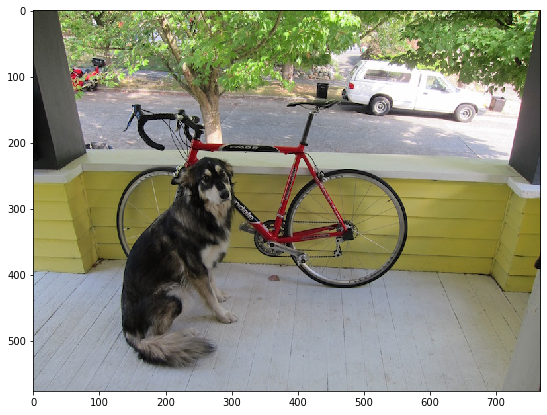

```python
img = cv2.imread('images/dog.jpg')
img = cv2.cvtColor(img, cv2.COLOR_BGR2RGB)
plt.figure(figsize = (20, 20))
plt.subplot(1, 2, 1); plt.imshow(img)
img.shape
```

```
(424, 640, 3)
```

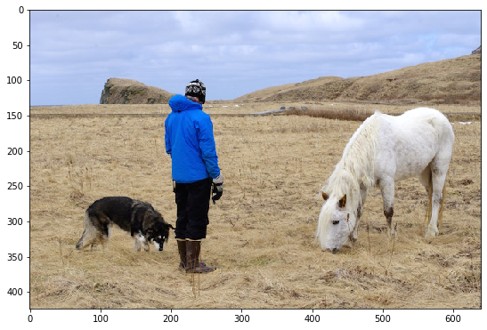

```python
img = cv2.imread('images/person.jpg')
img1 = cv2.cvtColor(img, cv2.COLOR_BGR2RGB)
plt.figure(figsize = (20, 20))
plt.subplot(1, 2, 1); plt.imshow(img1)
img1.shape
```

```python
img = cv2.imread('images/biking.jpg')
img1 = cv2.cvtColor(img, cv2.COLOR_BGR2RGB)
plt.figure(figsize = (20, 20))
plt.subplot(1, 2, 1); plt.imshow(img1)
img1.shape
```

[output not shown]

```python
## 載入相關函式庫 - Load related library
```

''' >> Faster RCNN model >> 預訓練模型 model_zoo.get_model(' ') - net = model_zoo.get_model('faster_rcnn_resnet50_v1b_voc', pretrained=True) '''

```python
from matplotlib import pyplot as plt
import gluoncv
from gluoncv import model_zoo, data, utils
```

```python
## 加載預訓練的模型  - Load faster_rcnn_resnet50_v1b_voc
```

```python
net = model_zoo.get_model('faster_rcnn_resnet50_v1b_voc', pretrained=True)
```

```python
## 預處理圖像 Pre-process an image
```

''' - 預處理圖像 -------------------- - 下載圖像 - 使用預設的數據轉換 - 進行預處理 - 默認 - 圖像的短邊尺寸調整為600px - 可以提供任意大小的圖像。 - >> gluoncv.data.transforms.presets.rcnn.load_test - 形狀為（batch_size，RGB_channels，height，width）的 NDArray - 可以直接將其 輸入模型 - 加載單個圖像 - x 第一維為 1 - orig_img - 大小 - 已調整為短邊 600px '''

```python
ddir
```

```python
im_fname = utils.download('person.jpg')

x, orig_img = data.transforms.presets.rcnn.load_test(im_fname)
print('Shape of pre-processed image:', x.shape)
```

```
Shape of pre-processed image: (1, 3, 600, 906)
```

```python
im_fname = utils.download('dog.jpg')

x, orig_img = data.transforms.presets.rcnn.load_test(im_fname)
print('Shape of pre-processed image:', x.shape)
```

```
Shape of pre-processed image: (1, 3, 600, 800)
```

```python
im_fname = utils.download('https://github.com/dmlc/web-data/blob/master/' +
                          'gluoncv/detection/biking.jpg?raw=true',
                          path='biking.jpg')
x, orig_img = data.transforms.presets.rcnn.load_test(im_fname)
print('Shape of pre-processed image:', x.shape)
```

```
Shape of pre-processed image: (1, 3, 600, 956)
```

```python
## 檢/ 偵測 和 顯示 - Detection and Display
```

''' -Faster RCNN 模型 - - 返回預測 ID - 置信度得分 - 邊界框坐標 - 形狀 - batch_size，num_bboxes，1 - batch_size，num_bboxes，1 - batch_size，num_bboxes，4 - 物體 - 檢測結果 - 可以使用： - py：func：- gluoncv.utils.viz.plot_bbox - 可視化結果 -第一張圖片的結果進行切片 - 並將其輸入 - plot_bbox '''

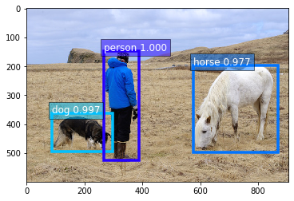

```
Wall time: 14.5 s
```

```python
%%time
box_ids, scores, bboxes = net(x)
ax = utils.viz.plot_bbox(orig_img, bboxes[0], scores[0], box_ids[0], class_names=net.classes)

plt.show()
```

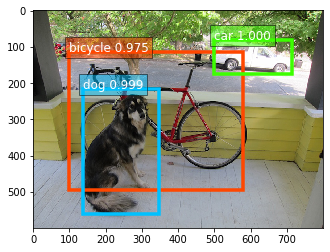

```
Wall time: 14.6 s
```

```python
%%time
box_ids, scores, bboxes = net(x)
ax = utils.viz.plot_bbox(orig_img, bboxes[0], scores[0], box_ids[0], class_names=net.classes)

plt.show()
```

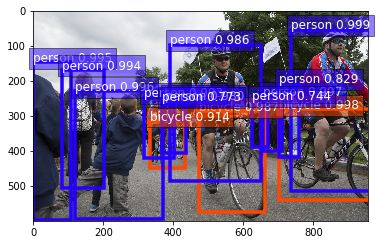

```
Wall time: 15.2 s
```

```python
%%time
box_ids, scores, bboxes = net(x)
ax = utils.viz.plot_bbox(orig_img, bboxes[0], scores[0], box_ids[0], class_names=net.classes)

plt.show()
```